# Proyecto Integrador de Ciencia de Datos — Fase 1

## Asociación entre cobertura de seguro médico y enfermedad reciente en Paraguay: análisis de la EPHC 2024

**Grupo 4**  
Kyara Ivanna Popov Araujo · Zinri Alice Bobadilla Peralta · Alejandro Sanabria Penayo

Este notebook documenta de forma reproducible la comprensión, selección, limpieza y análisis de los datos.

## Etapa 2 — Comprensión y selección de los datos

Fuente principal: INE Paraguay, EPHC Anual 2024, base de población REG02.

El archivo original debe permanecer intacto en `data/raw/REG02_EPHC_ANUAL_2024.csv`.

```python
from pathlib import Path
import pandas as pd
import numpy as np

DATA_PATH = Path("../data/raw/REG02_EPHC_ANUAL_2024.csv")

df_raw = pd.read_csv(
    DATA_PATH,
    sep=";",
    encoding="utf-8-sig",
    low_memory=False
)

print(f"Filas: {df_raw.shape[0]:,}")
print(f"Columnas: {df_raw.shape[1]}")
print(df_raw["AÑO"].value_counts(dropna=False))
```

```
Filas: 57,744
Columnas: 213
AÑO
2024    57744
Name: count, dtype: int64
```

### 2.1 Unidad de análisis y clave

La unidad de análisis es la persona integrante de un hogar encuestado.  
Se verifica la unicidad de la clave compuesta `UPM + NVIVI + NHOGA + L02`.

```python
clave_persona = ["UPM", "NVIVI", "NHOGA", "L02"]

duplicados_clave = df_raw.duplicated(subset=clave_persona).sum()

print("Registros:", len(df_raw))
print("Claves únicas:", df_raw[clave_persona].drop_duplicates().shape[0])
print("Duplicados según clave:", duplicados_clave)
```

```
Registros: 57744
Claves únicas: 57744
Duplicados según clave: 0
```

### 2.2 Variables seleccionadas

Se conserva un subconjunto relacionado con los objetivos del proyecto. Los identificadores quedan solo para trazabilidad.

```python
factor_origen = "FEX.2022" if "FEX.2022" in df_raw.columns else "FACTOR"

variables_seleccionadas = [
    "UPM", "NVIVI", "NHOGA", "L02",
    "AÑO", "DPTO", "AREA",
    "P02", "P06", "P09",
    "S01A", "S03",
    factor_origen,
    "añoest", "ipcm", "quintili"
]

df_sel = df_raw[variables_seleccionadas].copy()

print("Factor de expansión detectado:", factor_origen)
df_sel.head()
```

```
Factor de expansión detectado: FACTOR
```

|  | UPM | NVIVI | NHOGA | L02 | AÑO | DPTO | AREA | P02 | P06 | P09 | S01A | S03 | FACTOR | añoest | ipcm | quintili |
| --- | --- | --- | --- | --- | --- | --- | --- | --- | --- | --- | --- | --- | --- | --- | --- | --- |
| 0 | 14 | 3 | 1 | 2 | 2024 | 0 | 1 | 40 | 1 | 2 | 1 | 3 | 72 | 12 | 4035459,49658286 | 5 |
| 1 | 14 | 3 | 1 | 6 | 2024 | 0 | 1 | 38 | 6 | 2 | 7 | 3 | 72 | 12 | 4035459,49658286 | 5 |
| 2 | 14 | 15 | 1 | 1 | 2024 | 0 | 1 | 78 | 1 | 1 | 1 | 3 | 68 | 6 | 1782061,06870229 | 3 |
| 3 | 14 | 15 | 1 | 2 | 2024 | 0 | 1 | 77 | 6 | 1 | 1 | 3 | 68 | 12 | 1782061,06870229 | 3 |
| 4 | 14 | 23 | 1 | 1 | 2024 | 0 | 1 | 32 | 1 | 1 | 4 | 3 | 75 | 13 | 5931717,5572519 | 5 |

### 2.3 Perfilado inicial

Los espacios vacíos se interpretan aquí únicamente para medir completitud. La limpieza definitiva se hará en la Etapa 3.

```python
def faltantes_reales(serie):
    if serie.dtype == "object":
        s = serie.astype("string").str.strip()
        return s.isna() | s.eq("")
    return serie.isna()

perfil = []

for col in df_sel.columns:
    faltantes = faltantes_reales(df_sel[col])
    perfil.append({
        "variable": col,
        "dtype_detectado": str(df_sel[col].dtype),
        "faltantes": int(faltantes.sum()),
        "faltantes_pct": round(faltantes.mean() * 100, 3),
        "cardinalidad": int(df_sel.loc[~faltantes, col].nunique())
    })

perfil_df = pd.DataFrame(perfil)
perfil_df
```

|  | variable | dtype_detectado | faltantes | faltantes_pct | cardinalidad |
| --- | --- | --- | --- | --- | --- |
| 0 | UPM | int64 | 0 | 0.000 | 1750 |
| 1 | NVIVI | int64 | 0 | 0.000 | 140 |
| 2 | NHOGA | int64 | 0 | 0.000 | 3 |
| 3 | L02 | int64 | 0 | 0.000 | 27 |
| 4 | AÑO | int64 | 0 | 0.000 | 1 |
| 5 | DPTO | int64 | 0 | 0.000 | 16 |
| 6 | AREA | int64 | 0 | 0.000 | 2 |
| 7 | P02 | int64 | 0 | 0.000 | 105 |
| 8 | P06 | int64 | 0 | 0.000 | 2 |
| 9 | P09 | int64 | 0 | 0.000 | 6 |
| 10 | S01A | int64 | 0 | 0.000 | 7 |
| 11 | S03 | int64 | 0 | 0.000 | 4 |
| 12 | FACTOR | int64 | 0 | 0.000 | 470 |
| 13 | añoest | object | 3541 | 6.132 | 20 |
| 14 | ipcm | object | 130 | 0.225 | 13765 |
| 15 | quintili | object | 130 | 0.225 | 5 |

### 2.4 Auditoría de categorías principales

```python
for col in ["AREA", "P06", "P09", "S01A", "S03", "quintili"]:
    print(f"\n--- {col} ---")
    print(df_raw[col].astype("string").str.strip().replace("", pd.NA).value_counts(dropna=False).sort_index())
```

```
--- AREA ---
AREA
1    33278
6    24466
Name: count, dtype: Int64

--- P06 ---
P06
1    28599
6    29145
Name: count, dtype: Int64

--- P09 ---
P09
1    12954
2    10686
3     1574
4     2204
5    30075
6      251
Name: count, dtype: Int64

--- S01A ---
S01A
1    11389
2      281
3      550
4     2254
5      306
6      509
7    42455
Name: count, dtype: Int64

--- S03 ---
S03
1    17162
2      631
3    39947
9        4
Name: count, dtype: Int64

--- quintili ---
quintili
1       13869
2       12092
3       10989
4       10372
5       10292
<NA>      130
Name: count, dtype: Int64
```

### 2.5 Auditoría de segunda cobertura de seguro

El cuestionario admite una segunda cobertura en `S01B`. Verificamos que una persona codificada como “sin seguro” en `S01A` no tenga una segunda cobertura registrada.

```python
s01b = df_raw["S01B"].astype("string").str.strip().replace("", pd.NA)

print("Registros con segunda cobertura:", s01b.notna().sum())

inconsistentes_seguro = (
    df_raw["S01A"].eq(7) & s01b.notna()
).sum()

print("S01A = 7 con S01B informado:", inconsistentes_seguro)
```

```
Registros con segunda cobertura: 1141
S01A = 7 con S01B informado: 0
```

### 2.6 Tipos detectados frente a tipos correctos

Las variables categóricas codificadas con números no deben interpretarse como cantidades.  
`ipcm`, `añoest` y `quintili` presentan espacios o valores especiales y serán normalizadas en la Etapa 3.

```python
df_sel.dtypes.to_frame("dtype_detectado")
```

|  | dtype_detectado |
| --- | --- |
| UPM | int64 |
| NVIVI | int64 |
| NHOGA | int64 |
| L02 | int64 |
| AÑO | int64 |
| DPTO | int64 |
| AREA | int64 |
| P02 | int64 |
| P06 | int64 |
| P09 | int64 |
| S01A | int64 |
| S03 | int64 |
| FACTOR | int64 |
| añoest | object |
| ipcm | object |
| quintili | object |

### 2.7 Dimensión temporal

La base anual contiene `AÑO = 2024`, pero no incluye trimestre ni fecha de entrevista. Por ello, la dimensión temporal se complementa con los cuatro REG02 trimestrales oficiales de 2024, manteniendo la base anual como fuente principal del análisis.

Los REG02 trimestrales disponibles no contienen las variables de salud `S01A` y `S03`. En consecuencia, no es posible construir una prevalencia trimestral de enfermedad o cobertura con estos archivos sin recurrir a otra fuente. Para cumplir el requisito de serie temporal sin inventar datos, se utiliza una variable común y metodológicamente relevante para el proyecto: `AREA`, que además mostró diferencias descriptivas de enfermedad en el análisis anual.

## Próximo paso — Etapa 3: Limpieza y transformación

Se trabajará siempre sobre una copia de los datos y se documentará cada modificación:

- normalización de faltantes y tipos;
- tratamiento de códigos especiales;
- exclusión de accidentados para el dataset analítico principal;
- creación de `tiene_seguro`;
- creación de `enfermedad_reciente`;
- tratamiento de `añoest`, `ipcm` y `quintili`;
- preparación del factor de expansión;
- bitácora de limpieza;
- exportación del dataset limpio.

## Etapa 3 — Limpieza y transformación

Se trabaja sobre una copia de las variables seleccionadas. El archivo original no se modifica.

Criterios principales:

- espacios vacíos → `NaN`;
- conversión de números almacenados con coma decimal;
- `añoest=99` → `NaN`;
- accidentados (`S03=2`) fuera del dataset analítico principal;
- código no válido `S03=9` fuera del dataset analítico;
- creación de `tiene_seguro` y `enfermedad_reciente`;
- no se imputan todavía variables socioeconómicas.

```python
factor_origen = "FEX.2022" if "FEX.2022" in df_raw.columns else "FACTOR"

variables_origen = [
    "UPM", "NVIVI", "NHOGA", "L02",
    "AÑO", "DPTO", "AREA",
    "P02", "P06", "P09",
    "S01A", "S03",
    factor_origen, "añoest", "ipcm", "quintili",
]

df = df_raw[variables_origen].copy()

for col in df.select_dtypes(include="object").columns:
    df[col] = (
        df[col]
        .astype("string")
        .str.strip()
        .replace("", pd.NA)
    )
```

```python
def decimal_coma_a_numero(serie):
    return pd.to_numeric(
        serie.astype("string").str.replace(",", ".", regex=False),
        errors="coerce"
    )

df["factor_expansion"] = decimal_coma_a_numero(df[factor_origen])
df["ingreso_per_capita_mensual"] = decimal_coma_a_numero(df["ipcm"])

df["anios_estudio"] = pd.to_numeric(df["añoest"], errors="coerce")
df.loc[df["anios_estudio"].eq(99), "anios_estudio"] = np.nan

df["quintil_ingreso"] = pd.to_numeric(
    df["quintili"], errors="coerce"
).astype("Int64")
```

```python
map_dpto = {
    0: "Asunción", 1: "Concepción", 2: "San Pedro", 3: "Cordillera",
    4: "Guairá", 5: "Caaguazú", 6: "Caazapá", 7: "Itapúa",
    8: "Misiones", 9: "Paraguarí", 10: "Alto Paraná", 11: "Central",
    12: "Ñeembucú", 13: "Amambay", 14: "Canindeyú",
    15: "Presidente Hayes",
}
map_area = {1: "Urbana", 6: "Rural"}
map_sexo = {1: "Hombre", 6: "Mujer"}
map_estado_civil = {
    1: "Casado/a", 2: "Unido/a", 3: "Separado/a",
    4: "Viudo/a", 5: "Soltero/a", 6: "Divorciado/a"
}
map_seguro = {
    1: "IPS", 2: "Seguro privado individual",
    3: "Seguro privado laboral", 4: "Seguro privado familiar",
    5: "Sanidad Militar", 6: "Sanidad Policial",
    7: "Sin seguro", 8: "Otro",
}
map_salud = {1: "Enfermo/a", 2: "Accidentado/a", 3: "Sano/a"}

df["departamento"] = df["DPTO"].map(map_dpto)
df["area"] = df["AREA"].map(map_area)
df["sexo"] = df["P06"].map(map_sexo)
df["estado_civil"] = df["P09"].map(map_estado_civil)
df["tipo_seguro"] = df["S01A"].map(map_seguro)
df["estado_salud_90d"] = df["S03"].map(map_salud)
```

```python
df["persona_id"] = (
    df["UPM"].astype(str) + "-" +
    df["NVIVI"].astype(str) + "-" +
    df["NHOGA"].astype(str) + "-" +
    df["L02"].astype(str)
)

df["tiene_seguro"] = np.where(
    df["S01A"].isin([1, 2, 3, 4, 5, 6, 8]),
    1, 0
)

df["enfermedad_reciente"] = pd.Series(
    pd.NA, index=df.index, dtype="Int8"
)
df.loc[df["S03"].eq(1), "enfermedad_reciente"] = 1
df.loc[df["S03"].eq(3), "enfermedad_reciente"] = 0
```

```python
print("Registros originales:", len(df))
print("Accidentados (S03=2):", (df["S03"] == 2).sum())
print("Código no válido S03=9:", (df["S03"] == 9).sum())

df_clean = df[df["S03"].isin([1, 3])].copy()

print("Registros del dataset analítico:", len(df_clean))
```

```
Registros originales: 57744
Accidentados (S03=2): 631
Código no válido S03=9: 4
Registros del dataset analítico: 57109
```

### Decisión sobre valores faltantes

No se imputan `anios_estudio`, `ingreso_per_capita_mensual` ni `quintil_ingreso` en esta fase.  
Eliminar o rellenar sin estudiar primero el mecanismo y el impacto de los faltantes podría introducir sesgo. La estrategia para modelado se definirá posteriormente dentro del pipeline de entrenamiento.

```python
resumen_faltantes = pd.DataFrame({
    "faltantes": df_clean[
        ["anios_estudio", "ingreso_per_capita_mensual", "quintil_ingreso"]
    ].isna().sum()
})
resumen_faltantes["porcentaje"] = (
    resumen_faltantes["faltantes"] / len(df_clean) * 100
)
resumen_faltantes
```

|  | faltantes | porcentaje |
| --- | --- | --- |
| anios_estudio | 3543 | 6.203926 |
| ingreso_per_capita_mensual | 130 | 0.227635 |
| quintil_ingreso | 130 | 0.227635 |

### Exportación

El archivo final de esta etapa es `ephc_salud_2024_limpio.csv`.  
La exportación se realiza por código y puede regenerarse desde el archivo original.

```python
# Renombramos las variables con nombres legibles y conservamos solo las 25 columnas finales.
df_clean = df_clean.rename(columns={
    "AÑO": "anio",
    "DPTO": "departamento_codigo",
    "AREA": "area_codigo",
    "P02": "edad",
    "P06": "sexo_codigo",
    "P09": "estado_civil_codigo",
    "S01A": "seguro_codigo",
    "S03": "salud_90d_codigo",
})

columnas_finales = [
    "persona_id", "UPM", "NVIVI", "NHOGA", "L02",
    "anio", "departamento_codigo", "departamento",
    "area_codigo", "area", "edad",
    "sexo_codigo", "sexo",
    "estado_civil_codigo", "estado_civil",
    "seguro_codigo", "tipo_seguro", "tiene_seguro",
    "salud_90d_codigo", "estado_salud_90d", "enfermedad_reciente",
    "factor_expansion", "anios_estudio",
    "ingreso_per_capita_mensual", "quintil_ingreso",
]

df_clean = df_clean[columnas_finales].copy()

OUTPUT_PATH = Path("../data/processed/ephc_salud_2024_limpio.csv")
OUTPUT_PATH.parent.mkdir(parents=True, exist_ok=True)
df_clean.to_csv(OUTPUT_PATH, index=False)

print("Dataset limpio exportado en:", OUTPUT_PATH)
print("Dimensiones finales:", df_clean.shape)
df_clean.head()
```

```
Dataset limpio exportado en: ../data/processed/ephc_salud_2024_limpio.csv
Dimensiones finales: (57109, 25)
```

|  | persona_id | UPM | NVIVI | NHOGA | L02 | anio | departamento_codigo | departamento | area_codigo | area | edad | sexo_codigo | sexo | estado_civil_codigo | estado_civil | seguro_codigo | tipo_seguro | tiene_seguro | salud_90d_codigo | estado_salud_90d | enfermedad_reciente | factor_expansion | anios_estudio | ingreso_per_capita_mensual | quintil_ingreso |
| --- | --- | --- | --- | --- | --- | --- | --- | --- | --- | --- | --- | --- | --- | --- | --- | --- | --- | --- | --- | --- | --- | --- | --- | --- | --- |
| 0 | 14-3-1-2 | 14 | 3 | 1 | 2 | 2024 | 0 | Asunción | 1 | Urbana | 40 | 1 | Hombre | 2 | Unido/a | 1 | IPS | 1 | 3 | Sano/a | 0 | 72 | 12 | 4035459.496583 | 5 |
| 1 | 14-3-1-6 | 14 | 3 | 1 | 6 | 2024 | 0 | Asunción | 1 | Urbana | 38 | 6 | Mujer | 2 | Unido/a | 7 | Sin seguro | 0 | 3 | Sano/a | 0 | 72 | 12 | 4035459.496583 | 5 |
| 2 | 14-15-1-1 | 14 | 15 | 1 | 1 | 2024 | 0 | Asunción | 1 | Urbana | 78 | 1 | Hombre | 1 | Casado/a | 1 | IPS | 1 | 3 | Sano/a | 0 | 68 | 6 | 1782061.068702 | 3 |
| 3 | 14-15-1-2 | 14 | 15 | 1 | 2 | 2024 | 0 | Asunción | 1 | Urbana | 77 | 6 | Mujer | 1 | Casado/a | 1 | IPS | 1 | 3 | Sano/a | 0 | 68 | 12 | 1782061.068702 | 3 |
| 4 | 14-23-1-1 | 14 | 23 | 1 | 1 | 2024 | 0 | Asunción | 1 | Urbana | 32 | 1 | Hombre | 1 | Casado/a | 4 | Seguro privado familiar | 1 | 3 | Sano/a | 0 | 75 | 13 | 5931717.557252 | 5 |

## Etapa 4 — Análisis univariado y bivariado

En esta etapa se trabaja sobre el **dataset analítico limpio de 57.109 personas**.

Se mantienen las decisiones metodológicas ya aprobadas:

- `enfermedad_reciente = 1` representa a personas que reportaron enfermedad en los últimos 90 días y `0` a personas sanas;
- los accidentados y los códigos no válidos de `S03` ya fueron excluidos en la Etapa 3;
- `tiene_seguro = 1` indica que la persona posee cobertura y `0` que no posee;
- los valores faltantes socioeconómicos se conservan sin imputación;
- `factor_expansion` se utiliza **cuando corresponde** para estimaciones que buscan representar a la población, sin mezclarlo con las frecuencias observadas de la muestra.

Los resultados de esta etapa son **descriptivos**. Las diferencias observadas no se interpretan todavía como significativas ni causales.

```python
# Librerías para visualización.
import matplotlib.pyplot as plt
import seaborn as sns

# Creamos una copia exclusiva para el análisis, sin modificar el dataset limpio exportado.
df_analisis = df_clean.copy()

df_analisis["cobertura_seguro"] = df_analisis["tiene_seguro"].map({
    0: "Sin seguro",
    1: "Con seguro"
})

df_analisis["enfermedad"] = df_analisis["enfermedad_reciente"].map({
    0: "Sano/a",
    1: "Enfermo/a"
})

print("Registros analizados:", len(df_analisis))
```

```
Registros analizados: 57109
```

### 4.1 Análisis univariado — Variables numéricas

Para las variables numéricas sustantivas se calculan las medidas solicitadas por la consigna: media, mediana, moda, desviación estándar, coeficiente de variación, mínimo, máximo, rango intercuartílico, percentiles, asimetría y curtosis.

`factor_expansion` no se trata como una característica sustantiva de la persona: es una variable técnica de ponderación.

```python
variables_numericas = [
    "edad",
    "anios_estudio",
    "ingreso_per_capita_mensual"
]

nombres_numericas = {
    "edad": "Edad",
    "anios_estudio": "Años de estudio",
    "ingreso_per_capita_mensual": "Ingreso per cápita mensual"
}

resumen_numericas = []

for variable in variables_numericas:
    datos = df_analisis[variable].dropna()
    percentiles = datos.quantile([0.05, 0.25, 0.50, 0.75, 0.95])

    resumen_numericas.append({
        "Variable": nombres_numericas[variable],
        "N": datos.count(),
        "Faltantes": df_analisis[variable].isna().sum(),
        "Media": datos.mean(),
        "Mediana": datos.median(),
        "Moda": datos.mode().iloc[0],
        "Desv. estándar": datos.std(),
        "CV (%)": datos.std() / datos.mean() * 100 if datos.mean() != 0 else np.nan,
        "Mínimo": datos.min(),
        "Máximo": datos.max(),
        "IQR": percentiles.loc[0.75] - percentiles.loc[0.25],
        "P5": percentiles.loc[0.05],
        "P25": percentiles.loc[0.25],
        "P50": percentiles.loc[0.50],
        "P75": percentiles.loc[0.75],
        "P95": percentiles.loc[0.95],
        "Asimetría": datos.skew(),
        "Curtosis": datos.kurt(),
    })

resumen_numericas = pd.DataFrame(resumen_numericas)
resumen_numericas.round(2)
```

|  | Variable | N | Faltantes | Media | Mediana | Moda | Desv. estándar | CV (%) | Mínimo | Máximo | IQR | P5 | P25 | P50 | P75 | P95 | Asimetría | Curtosis |
| --- | --- | --- | --- | --- | --- | --- | --- | --- | --- | --- | --- | --- | --- | --- | --- | --- | --- | --- |
| 0 | Edad | 57109 | 0 | 32.95 | 30.00 | 10.00 | 21.92 | 66.53 | 0.0 | 1.060000e+02 | 35.0 | 3.00 | 14.0 | 30.00 | 49.0 | 72.00 | 0.46 | -0.69 |
| 1 | Años de estudio | 53566 | 3543 | 8.17 | 8.00 | 12.00 | 5.03 | 61.62 | 0.0 | 1.800000e+01 | 8.0 | 0.00 | 4.0 | 8.00 | 12.0 | 16.00 | 0.09 | -1.04 |
| 2 | Ingreso per cápita mensual | 56979 | 130 | 1979469.92 | 1357053.65 | 999250.94 | 2683407.79 | 135.56 | 0.0 | 1.467867e+08 | 1483911.5 | 373384.22 | 807500.0 | 1357053.65 | 2291411.5 | 5213533.88 | 11.19 | 282.31 |

**Análisis:**

- La **edad** tiene media de aproximadamente **32,95 años** y mediana de **30 años**. La asimetría positiva es leve, por lo que ambas medidas resumen razonablemente el centro, aunque la mediana es más robusta.
- Los **años de estudio** presentan media de aproximadamente **8,17** y mediana de **8**. La asimetría es cercana a cero, aunque la variable es discreta y se concentra en niveles educativos concretos.
- El **ingreso per cápita mensual** es claramente asimétrico hacia la derecha: la media ronda **1,98 millones de Gs.**, mientras que la mediana es cercana a **1,36 millones de Gs.**. Además, el máximo es muy elevado respecto del percentil 95. Por ello, la **mediana y los percentiles son más adecuados que la media** para describir un ingreso típico.

Los valores extremos de ingreso se conservan: un valor atípico no se elimina solamente por estar alejado del resto.

#### Distribución de la edad

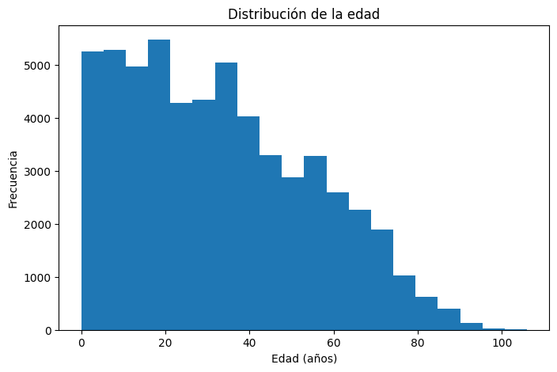

```python
plt.figure(figsize=(8, 5))
df_analisis["edad"].plot(kind="hist", bins=20)
plt.title("Distribución de la edad")
plt.xlabel("Edad (años)")
plt.ylabel("Frecuencia")
plt.show()
```

**Análisis:** la distribución de la edad es amplia y presenta una leve asimetría hacia valores mayores. No se observa una forma normal perfecta; la muestra contiene personas de todo el ciclo de vida.

#### Distribución de los años de estudio

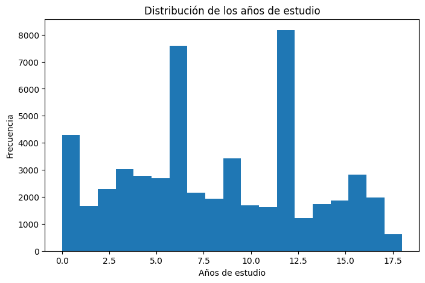

```python
plt.figure(figsize=(8, 5))
df_analisis["anios_estudio"].dropna().plot(kind="hist", bins=19)
plt.title("Distribución de los años de estudio")
plt.xlabel("Años de estudio")
plt.ylabel("Frecuencia")
plt.show()
```

**Análisis:** los años de estudio toman valores discretos y muestran concentraciones en determinados niveles educativos. Se mantienen los faltantes sin imputación, por lo que el gráfico representa solamente los registros con información disponible.

#### Distribución del ingreso per cápita mensual

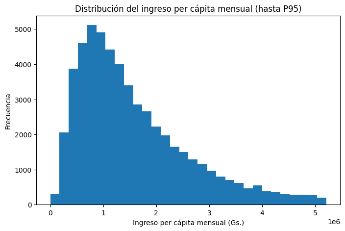

```python
# El ingreso tiene valores extremos muy altos. Para ver la forma principal de la distribución,
# mostramos hasta el percentil 95 SOLO en este gráfico. No se eliminan registros del dataset.
limite_ingreso_p95 = df_analisis["ingreso_per_capita_mensual"].quantile(0.95)
ingresos_hasta_p95 = df_analisis.loc[
    df_analisis["ingreso_per_capita_mensual"] <= limite_ingreso_p95,
    "ingreso_per_capita_mensual"
]

plt.figure(figsize=(8, 5))
ingresos_hasta_p95.dropna().plot(kind="hist", bins=30)
plt.title("Distribución del ingreso per cápita mensual (hasta P95)")
plt.xlabel("Ingreso per cápita mensual (Gs.)")
plt.ylabel("Frecuencia")
plt.show()
```

**Análisis:** incluso limitando la visualización al percentil 95, el ingreso conserva una cola hacia la derecha. El gráfico se recorta únicamente para facilitar la lectura; el análisis estadístico anterior utiliza todos los valores válidos.

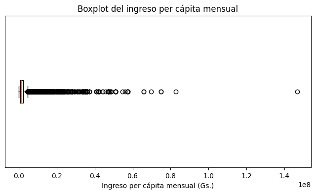

```python
plt.figure(figsize=(8, 4))
plt.boxplot(
    df_analisis["ingreso_per_capita_mensual"].dropna(),
    vert=False
)
plt.title("Boxplot del ingreso per cápita mensual")
plt.xlabel("Ingreso per cápita mensual (Gs.)")
plt.yticks([])
plt.show()
```

**Análisis:** el boxplot confirma la presencia de numerosos valores alejados del rango intercuartílico. Estos puntos se consideran valores extremos para describir la distribución, pero no se asumen como errores y por eso no se eliminan.

### 4.2 Análisis univariado — Variables categóricas

Para las variables categóricas se calculan frecuencias absolutas, frecuencias relativas y una medida simple de concentración: qué porcentaje de observaciones reúnen las categorías más frecuentes que corresponden aproximadamente al 20 % del número total de categorías.

```python
variables_categoricas = [
    "cobertura_seguro",
    "enfermedad",
    "tipo_seguro",
    "sexo",
    "area",
    "departamento",
    "estado_civil",
    "quintil_ingreso"
]

for variable in variables_categoricas:
    print(f"\n--- {variable} ---")
    tabla = (
        df_analisis[variable]
        .value_counts(dropna=False)
        .rename_axis("Categoría")
        .reset_index(name="Frecuencia")
    )
    tabla["Porcentaje (%)"] = tabla["Frecuencia"] / len(df_analisis) * 100
    display(tabla.round(2))
```

```
--- cobertura_seguro ---
```

|  | Categoría | Frecuencia | Porcentaje (%) |
| --- | --- | --- | --- |
| 0 | Sin seguro | 41991 | 73.53 |
| 1 | Con seguro | 15118 | 26.47 |

```
--- enfermedad ---
```

|  | Categoría | Frecuencia | Porcentaje (%) |
| --- | --- | --- | --- |
| 0 | Sano/a | 39947 | 69.95 |
| 1 | Enfermo/a | 17162 | 30.05 |

```
--- tipo_seguro ---
```

|  | Categoría | Frecuencia | Porcentaje (%) |
| --- | --- | --- | --- |
| 0 | Sin seguro | 41991 | 73.53 |
| 1 | IPS | 11264 | 19.72 |
| 2 | Seguro privado familiar | 2225 | 3.90 |
| 3 | Seguro privado laboral | 544 | 0.95 |
| 4 | Sanidad Policial | 506 | 0.89 |
| 5 | Sanidad Militar | 304 | 0.53 |
| 6 | Seguro privado individual | 275 | 0.48 |

```
--- sexo ---
```

|  | Categoría | Frecuencia | Porcentaje (%) |
| --- | --- | --- | --- |
| 0 | Mujer | 28909 | 50.62 |
| 1 | Hombre | 28200 | 49.38 |

```
--- area ---
```

|  | Categoría | Frecuencia | Porcentaje (%) |
| --- | --- | --- | --- |
| 0 | Urbana | 32928 | 57.66 |
| 1 | Rural | 24181 | 42.34 |

```
--- departamento ---
```

|  | Categoría | Frecuencia | Porcentaje (%) |
| --- | --- | --- | --- |
| 0 | Central | 9997 | 17.51 |
| 1 | Alto Paraná | 6739 | 11.80 |
| 2 | Itapúa | 4698 | 8.23 |
| 3 | Asunción | 4307 | 7.54 |
| 4 | San Pedro | 3462 | 6.06 |
| 5 | Caaguazú | 3258 | 5.70 |
| 6 | Caazapá | 2908 | 5.09 |
| 7 | Cordillera | 2905 | 5.09 |
| 8 | Canindeyú | 2829 | 4.95 |
| 9 | Misiones | 2683 | 4.70 |
| 10 | Amambay | 2503 | 4.38 |
| 11 | Guairá | 2412 | 4.22 |
| 12 | Paraguarí | 2319 | 4.06 |
| 13 | Concepción | 2185 | 3.83 |
| 14 | Presidente Hayes | 2160 | 3.78 |
| 15 | Ñeembucú | 1744 | 3.05 |

```
--- estado_civil ---
```

|  | Categoría | Frecuencia | Porcentaje (%) |
| --- | --- | --- | --- |
| 0 | Soltero/a | 29802 | 52.18 |
| 1 | Casado/a | 12795 | 22.40 |
| 2 | Unido/a | 10557 | 18.49 |
| 3 | Viudo/a | 2162 | 3.79 |
| 4 | Separado/a | 1544 | 2.70 |
| 5 | Divorciado/a | 249 | 0.44 |

```
--- quintil_ingreso ---
```

|  | Categoría | Frecuencia | Porcentaje (%) |
| --- | --- | --- | --- |
| 0 | 1 | 13737 | 24.05 |
| 1 | 2 | 11940 | 20.91 |
| 2 | 3 | 10867 | 19.03 |
| 3 | 4 | 10265 | 17.97 |
| 4 | 5 | 10170 | 17.81 |
| 5 | <NA> | 130 | 0.23 |

```python
concentracion = []

for variable in variables_categoricas:
    frecuencias = df_analisis[variable].dropna().value_counts()
    cantidad_categorias = len(frecuencias)
    categorias_top = max(1, int(np.ceil(cantidad_categorias * 0.20)))
    porcentaje_top = frecuencias.head(categorias_top).sum() / frecuencias.sum() * 100

    concentracion.append({
        "Variable": variable,
        "Cantidad de categorías": cantidad_categorias,
        "20 % superior (n categorías)": categorias_top,
        "Concentración (%)": porcentaje_top
    })

pd.DataFrame(concentracion).round(2)
```

|  | Variable | Cantidad de categorías | 20 % superior (n categorías) | Concentración (%) |
| --- | --- | --- | --- | --- |
| 0 | cobertura_seguro | 2 | 1 | 73.53 |
| 1 | enfermedad | 2 | 1 | 69.95 |
| 2 | tipo_seguro | 7 | 2 | 93.25 |
| 3 | sexo | 2 | 1 | 50.62 |
| 4 | area | 2 | 1 | 57.66 |
| 5 | departamento | 16 | 4 | 45.07 |
| 6 | estado_civil | 6 | 2 | 74.59 |
| 7 | quintil_ingreso | 5 | 1 | 24.11 |

**Análisis:**

- En la muestra, aproximadamente **73,53 %** de las personas no posee seguro y **26,47 %** sí posee.
- Aproximadamente **30,05 %** reportó enfermedad reciente y **69,95 %** se clasificó como sano/a.
- El sexo está prácticamente equilibrado y el área urbana concentra una mayor proporción de registros que el área rural.
- En `tipo_seguro` existe una concentración marcada: **Sin seguro + IPS reúnen aproximadamente 93,25 %** de los registros.
- En departamentos, las cuatro categorías más frecuentes —que representan el 20 % de las 16 categorías— concentran aproximadamente **45,07 %** de la muestra.

#### Frecuencias observadas y estimaciones ponderadas

```python
def distribucion_ponderada(variable):
    pesos = df_analisis.groupby(variable, dropna=False)["factor_expansion"].sum()
    return pesos / pesos.sum() * 100

comparacion_seguro = pd.DataFrame({
    "Muestra (%)": df_analisis["cobertura_seguro"].value_counts(normalize=True) * 100,
    "Ponderado (%)": distribucion_ponderada("cobertura_seguro")
}).round(2)

comparacion_enfermedad = pd.DataFrame({
    "Muestra (%)": df_analisis["enfermedad"].value_counts(normalize=True) * 100,
    "Ponderado (%)": distribucion_ponderada("enfermedad")
}).round(2)

print("Cobertura de seguro")
display(comparacion_seguro)

print("Estado de salud en los últimos 90 días")
display(comparacion_enfermedad)
```

```
Cobertura de seguro
```

| cobertura_seguro | Muestra (%) | Ponderado (%) |
| --- | --- | --- |
| Con seguro | 26.47 | 30.14 |
| Sin seguro | 73.53 | 69.86 |

```
Estado de salud en los últimos 90 días
```

| enfermedad | Muestra (%) | Ponderado (%) |
| --- | --- | --- |
| Enfermo/a | 30.05 | 28.91 |
| Sano/a | 69.95 | 71.09 |

**Análisis:** al aplicar el factor de expansión, la proporción estimada con seguro aumenta respecto de la frecuencia observada en la muestra, mientras que la proporción estimada de enfermedad reciente disminuye ligeramente. Esto muestra por qué se mantiene la decisión de utilizar `factor_expansion` solamente cuando se pretende describir la población representada.

### 4.3 Análisis bivariado — Categórica frente a categórica

La relación principal del proyecto es **cobertura de seguro × enfermedad reciente**. Se construyen tablas de contingencia con frecuencias absolutas, porcentajes por fila y porcentajes por columna.

```python
tabla_absoluta = pd.crosstab(
    df_analisis["cobertura_seguro"],
    df_analisis["enfermedad"]
)

tabla_por_fila = pd.crosstab(
    df_analisis["cobertura_seguro"],
    df_analisis["enfermedad"],
    normalize="index"
) * 100

tabla_por_columna = pd.crosstab(
    df_analisis["cobertura_seguro"],
    df_analisis["enfermedad"],
    normalize="columns"
) * 100

print("Frecuencias absolutas")
display(tabla_absoluta)

print("Porcentajes por fila")
display(tabla_por_fila.round(2))

print("Porcentajes por columna")
display(tabla_por_columna.round(2))
```

```
Frecuencias absolutas
```

| enfermedad cobertura_seguro | Enfermo/a | Sano/a |
| --- | --- | --- |
| Con seguro | 4382 | 10736 |
| Sin seguro | 12780 | 29211 |

```
Porcentajes por fila
```

| enfermedad cobertura_seguro | Enfermo/a | Sano/a |
| --- | --- | --- |
| Con seguro | 28.99 | 71.01 |
| Sin seguro | 30.44 | 69.56 |

```
Porcentajes por columna
```

| enfermedad cobertura_seguro | Enfermo/a | Sano/a |
| --- | --- | --- |
| Con seguro | 25.53 | 26.88 |
| Sin seguro | 74.47 | 73.12 |

**Análisis:** en la muestra, aproximadamente **30,44 %** de las personas sin seguro reportó enfermedad reciente, frente a **28,99 %** entre quienes poseen seguro. La diferencia observada es pequeña y, en esta etapa, se interpreta solamente de forma descriptiva.

#### Comparación ponderada de enfermedad según cobertura

```python
comparacion_cobertura = []

for cobertura, grupo in df_analisis.groupby("cobertura_seguro"):
    porcentaje_muestra = grupo["enfermedad_reciente"].mean() * 100
    porcentaje_ponderado = np.average(
        grupo["enfermedad_reciente"],
        weights=grupo["factor_expansion"]
    ) * 100

    comparacion_cobertura.append({
        "Cobertura": cobertura,
        "Enfermedad en muestra (%)": porcentaje_muestra,
        "Enfermedad ponderada (%)": porcentaje_ponderado
    })

comparacion_cobertura = pd.DataFrame(comparacion_cobertura)
comparacion_cobertura.round(2)
```

|  | Cobertura | Enfermedad en muestra (%) | Enfermedad ponderada (%) |
| --- | --- | --- | --- |
| 0 | Con seguro | 28.99 | 27.99 |
| 1 | Sin seguro | 30.44 | 29.30 |

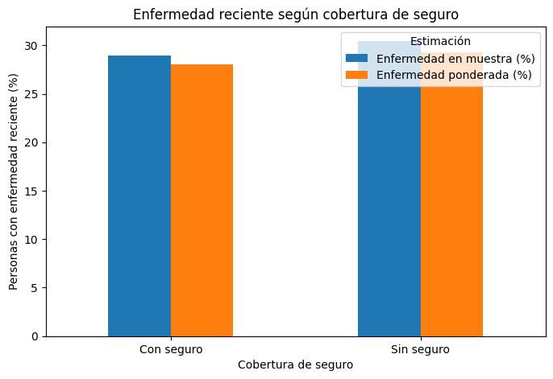

```python
grafico_cobertura = comparacion_cobertura.set_index("Cobertura")[[
    "Enfermedad en muestra (%)",
    "Enfermedad ponderada (%)"
]]

grafico_cobertura.plot(kind="bar", figsize=(8, 5))
plt.title("Enfermedad reciente según cobertura de seguro")
plt.xlabel("Cobertura de seguro")
plt.ylabel("Personas con enfermedad reciente (%)")
plt.xticks(rotation=0)
plt.legend(title="Estimación")
plt.show()
```

**Análisis:** con ponderación, la enfermedad reciente se estima en aproximadamente **29,30 %** entre personas sin seguro y **27,99 %** entre personas con seguro, una diferencia descriptiva de alrededor de **1,31 puntos porcentuales**. Esta diferencia no permite concluir todavía que exista una asociación estadísticamente significativa; eso se evaluará formalmente en la Fase 2.

#### Otras comparaciones categóricas con enfermedad reciente

```python
variables_comparacion = ["sexo", "area", "quintil_ingreso"]
comparaciones = []

for variable in variables_comparacion:
    for categoria, grupo in df_analisis.dropna(subset=[variable]).groupby(variable):
        porcentaje_ponderado = np.average(
            grupo["enfermedad_reciente"],
            weights=grupo["factor_expansion"]
        ) * 100

        comparaciones.append({
            "Variable": variable,
            "Categoría": categoria,
            "N": len(grupo),
            "Enfermedad ponderada (%)": porcentaje_ponderado
        })

pd.DataFrame(comparaciones).round(2)
```

|  | Variable | Categoría | N | Enfermedad ponderada (%) |
| --- | --- | --- | --- | --- |
| 0 | sexo | Hombre | 28200 | 26.50 |
| 1 | sexo | Mujer | 28909 | 31.34 |
| 2 | area | Rural | 24181 | 31.42 |
| 3 | area | Urbana | 32928 | 27.89 |
| 4 | quintil_ingreso | 1 | 13737 | 31.21 |
| 5 | quintil_ingreso | 2 | 11940 | 31.76 |
| 6 | quintil_ingreso | 3 | 10867 | 29.84 |
| 7 | quintil_ingreso | 4 | 10265 | 27.03 |
| 8 | quintil_ingreso | 5 | 10170 | 24.84 |

**Análisis:** descriptivamente, la prevalencia ponderada de enfermedad es mayor entre mujeres que entre hombres y mayor en el área rural que en la urbana. Por quintil de ingreso se observa una disminución general hacia los quintiles más altos, aunque el patrón no es perfectamente monotónico. Estas observaciones se retomarán en el análisis exploratorio antes de formular las hipótesis de la Fase 2.

### 4.4 Análisis bivariado — Numérica frente a categórica

Se comparan las distribuciones de edad, años de estudio e ingreso entre los grupos definidos por enfermedad reciente y por cobertura de seguro.

```python
resumen_por_enfermedad = (
    df_analisis
    .groupby("enfermedad")[variables_numericas]
    .agg(["count", "mean", "median", "std"])
)

resumen_por_enfermedad.round(2)
```

| enfermedad | edad count | edad mean | edad median | edad std | anios_estudio count | anios_estudio mean | anios_estudio median | anios_estudio std | ingreso_per_capita_mensual count | ingreso_per_capita_mensual mean | ingreso_per_capita_mensual median | ingreso_per_capita_mensual std |
| --- | --- | --- | --- | --- | --- | --- | --- | --- | --- | --- | --- | --- |
| Enfermo/a | 17162 | 35.35 | 33.0 | 24.47 | 15826 | 7.22 | 6.0 | 5.0 | 17141 | 1797672.37 | 1265418.17 | 2321467.11 |
| Sano/a | 39947 | 31.92 | 29.0 | 20.65 | 37740 | 8.57 | 9.0 | 4.99 | 39838 | 2057691.51 | 1398951.31 | 2821330.98 |

```python
resumen_por_seguro = (
    df_analisis
    .groupby("cobertura_seguro")[variables_numericas]
    .agg(["count", "mean", "median", "std"])
)

resumen_por_seguro.round(2)
```

| cobertura_seguro | edad count | edad mean | edad median | edad std | anios_estudio count | anios_estudio mean | anios_estudio median | anios_estudio std | ingreso_per_capita_mensual count | ingreso_per_capita_mensual mean | ingreso_per_capita_mensual median | ingreso_per_capita_mensual std |
| --- | --- | --- | --- | --- | --- | --- | --- | --- | --- | --- | --- | --- |
| Con seguro | 15118 | 36.26 | 35.0 | 22.53 | 14361 | 10.17 | 12.0 | 5.39 | 15094 | 3214274.42 | 2317371.6 | 3563800.38 |
| Sin seguro | 41991 | 31.76 | 28.0 | 21.58 | 39205 | 7.43 | 6.0 | 4.69 | 41885 | 1534486.29 | 1117154.06 | 2114572.43 |

**Análisis:**

- La edad mediana es de aproximadamente **33 años** entre quienes reportaron enfermedad y **29 años** entre quienes se clasificaron como sanos.
- La mediana de años de estudio es menor en el grupo con enfermedad reciente (**6**) que en el grupo sano (**9**).
- El ingreso mediano también es menor entre quienes reportaron enfermedad.
- Al comparar cobertura, las personas con seguro presentan mayores medianas de edad, años de estudio e ingreso que las personas sin seguro.

Estas diferencias muestran que los grupos con y sin seguro también difieren en otras características. Por ello, una diferencia de enfermedad no debe atribuirse directamente a la cobertura.

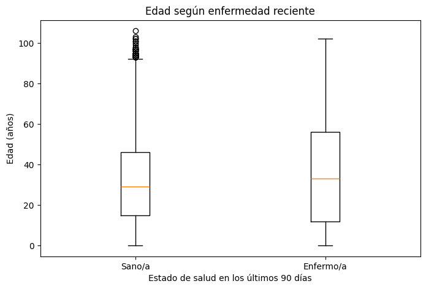

```python
plt.figure(figsize=(8, 5))
datos_edad = [
    df_analisis.loc[df_analisis["enfermedad"] == "Sano/a", "edad"].dropna(),
    df_analisis.loc[df_analisis["enfermedad"] == "Enfermo/a", "edad"].dropna()
]
plt.boxplot(datos_edad, labels=["Sano/a", "Enfermo/a"])
plt.title("Edad según enfermedad reciente")
plt.xlabel("Estado de salud en los últimos 90 días")
plt.ylabel("Edad (años)")
plt.show()
```

**Análisis:** el grupo que reportó enfermedad presenta una edad central algo mayor, además de una dispersión amplia en ambos grupos. El gráfico permite comparar la mediana, el rango intercuartílico y los posibles valores extremos.

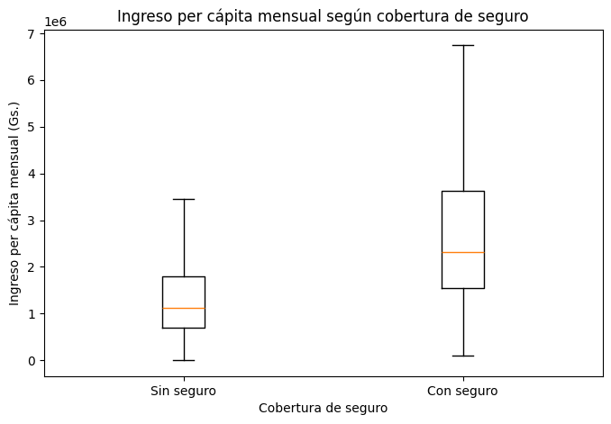

```python
# Para que la escala de ingreso sea legible en el boxplot se ocultan visualmente los puntos extremos.
# Los registros NO se eliminan y siguen participando de los estadísticos anteriores.
plt.figure(figsize=(8, 5))
datos_ingreso = [
    df_analisis.loc[
        df_analisis["cobertura_seguro"] == "Sin seguro",
        "ingreso_per_capita_mensual"
    ].dropna(),
    df_analisis.loc[
        df_analisis["cobertura_seguro"] == "Con seguro",
        "ingreso_per_capita_mensual"
    ].dropna()
]
plt.boxplot(datos_ingreso, labels=["Sin seguro", "Con seguro"], showfliers=False)
plt.title("Ingreso per cápita mensual según cobertura de seguro")
plt.xlabel("Cobertura de seguro")
plt.ylabel("Ingreso per cápita mensual (Gs.)")
plt.show()
```

**Análisis:** sin mostrar los puntos extremos para facilitar la lectura de las cajas, se observa que el ingreso central es mayor entre las personas con seguro. La ocultación de puntos es únicamente visual y no modifica el dataset ni los cálculos.

### 4.5 Análisis bivariado — Numérica frente a numérica

Se analizan las relaciones entre edad, años de estudio e ingreso per cápita mediante correlaciones de **Pearson** y **Spearman**, además de un diagrama de dispersión y mapas de calor.

```python
correlacion_pearson = df_analisis[variables_numericas].corr(method="pearson")
correlacion_spearman = df_analisis[variables_numericas].corr(method="spearman")

print("Correlación de Pearson")
display(correlacion_pearson.round(3))

print("Correlación de Spearman")
display(correlacion_spearman.round(3))
```

```
Correlación de Pearson
```

|  | edad | anios_estudio | ingreso_per_capita_mensual |
| --- | --- | --- | --- |
| edad | 1.000 | 0.091 | 0.112 |
| anios_estudio | 0.091 | 1.000 | 0.256 |
| ingreso_per_capita_mensual | 0.112 | 0.256 | 1.000 |

```
Correlación de Spearman
```

|  | edad | anios_estudio | ingreso_per_capita_mensual |
| --- | --- | --- | --- |
| edad | 1.000 | 0.168 | 0.177 |
| anios_estudio | 0.168 | 1.000 | 0.393 |
| ingreso_per_capita_mensual | 0.177 | 0.393 | 1.000 |

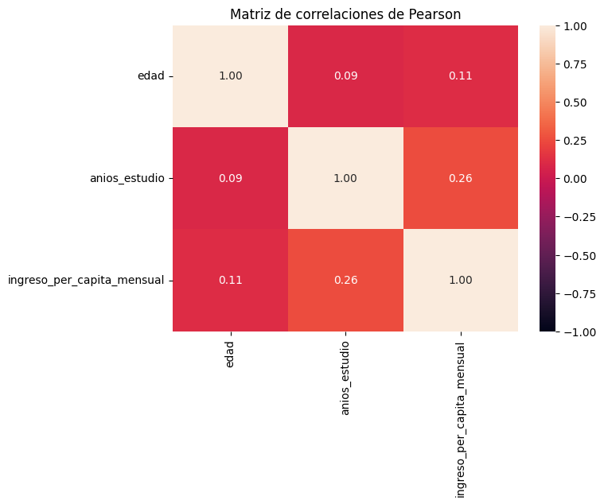

```python
plt.figure(figsize=(7, 5))
sns.heatmap(correlacion_pearson, annot=True, fmt=".2f", vmin=-1, vmax=1)
plt.title("Matriz de correlaciones de Pearson")
plt.show()
```

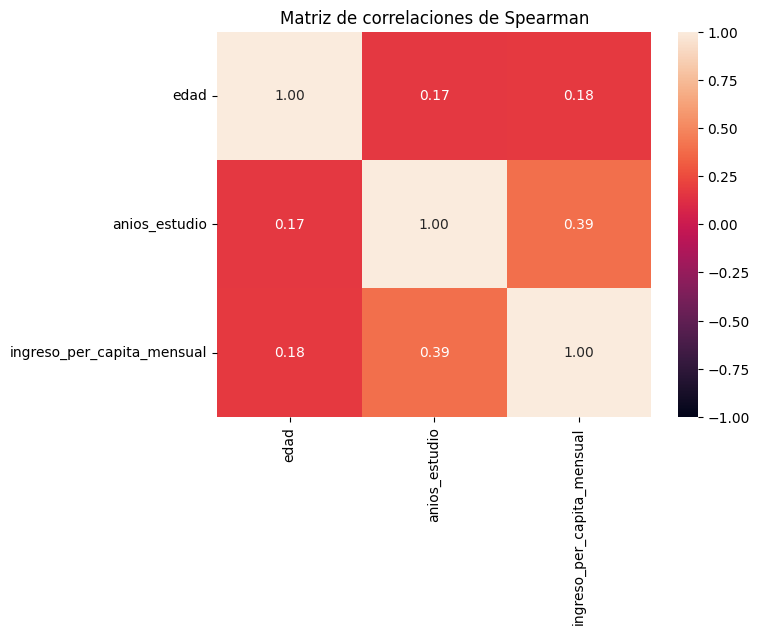

```python
plt.figure(figsize=(7, 5))
sns.heatmap(correlacion_spearman, annot=True, fmt=".2f", vmin=-1, vmax=1)
plt.title("Matriz de correlaciones de Spearman")
plt.show()
```

**Análisis:** las correlaciones lineales de Pearson son bajas. La relación más marcada aparece entre **años de estudio e ingreso**, con Pearson cercano a **0,26** y Spearman cercano a **0,39**. Que Spearman sea mayor es coherente con una relación monotónica afectada por la fuerte asimetría y los valores extremos del ingreso. En ningún caso la correlación se interpreta como causalidad.

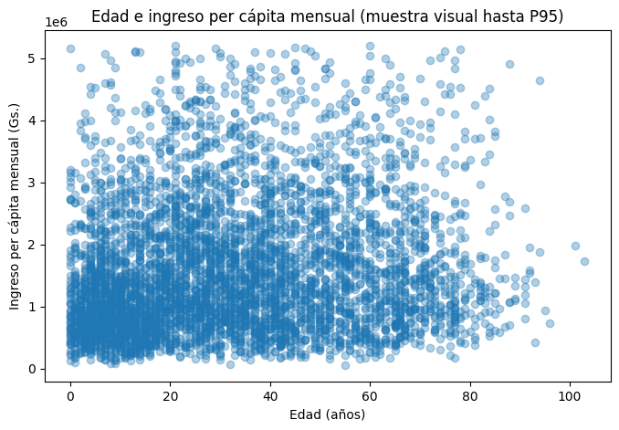

```python
# Para evitar sobreposición de decenas de miles de puntos se toma una muestra reproducible
# exclusivamente para el gráfico. También se limita el ingreso al P95 solo en la visualización.
muestra_scatter = df_analisis[
    df_analisis["ingreso_per_capita_mensual"] <= limite_ingreso_p95
].dropna(subset=["edad", "ingreso_per_capita_mensual"])

muestra_scatter = muestra_scatter.sample(
    n=min(5000, len(muestra_scatter)),
    random_state=42
)

plt.figure(figsize=(8, 5))
plt.scatter(
    muestra_scatter["edad"],
    muestra_scatter["ingreso_per_capita_mensual"],
    alpha=0.35
)
plt.title("Edad e ingreso per cápita mensual (muestra visual hasta P95)")
plt.xlabel("Edad (años)")
plt.ylabel("Ingreso per cápita mensual (Gs.)")
plt.show()
```

**Análisis:** el diagrama de dispersión no muestra una relación lineal fuerte entre edad e ingreso. La nube es amplia y heterogénea, consistente con los coeficientes de correlación bajos. El muestreo de puntos y el límite P95 se aplican únicamente para que el gráfico sea legible.

### 4.6 Análisis temporal

La base anual utilizada como dataset principal contiene únicamente `anio = 2024` y no dispone de trimestre ni fecha de entrevista. Por ello no es metodológicamente válido fabricar una serie temporal con ese archivo.

Se complementa la dimensión temporal con los cuatro REG02 trimestrales oficiales de 2024. Estos archivos no incluyen `S01A` ni `S03`, por lo que no permiten medir trimestralmente seguro médico o enfermedad reciente. Se utiliza `AREA` como variable temporal de contexto porque está presente en los cuatro trimestres, forma parte del dataset anual y resultó relevante en el análisis descriptivo de enfermedad.

### Cierre de la Etapa 4

El análisis descriptivo muestra una diferencia pequeña en la proporción de enfermedad reciente entre personas con y sin seguro. También aparecen diferencias por edad, educación, ingreso, sexo, área y quintil que deben considerarse al interpretar la relación principal.

Estos resultados **no constituyen todavía contrastes de hipótesis**. El siguiente paso es la **Etapa 5 — Análisis descriptivo y exploratorio (EDA)**, donde se seleccionarán y articularán las visualizaciones más informativas, se identificarán al menos tres patrones o anomalías con evidencia y, recién entonces, se formularán las hipótesis preliminares para la Fase 2.

## Etapa 5 — Análisis descriptivo y exploratorio (EDA)

En esta etapa se integran los resultados obtenidos en el análisis univariado y bivariado para caracterizar el fenómeno estudiado.

El objetivo no es repetir todos los estadísticos de la Etapa 4, sino seleccionar visualizaciones que permitan observar los principales patrones relacionados con:

- cobertura de seguro médico;
- enfermedad reciente;
- edad;
- sexo y área;
- nivel socioeconómico;
- relaciones entre variables numéricas.

Los resultados ponderados con `factor_expansion` se utilizan cuando se busca representar a la población. Los gráficos de distribución individual se mantienen principalmente sobre las observaciones de la muestra.

### 5.1 Enfermedad reciente según cobertura de seguro

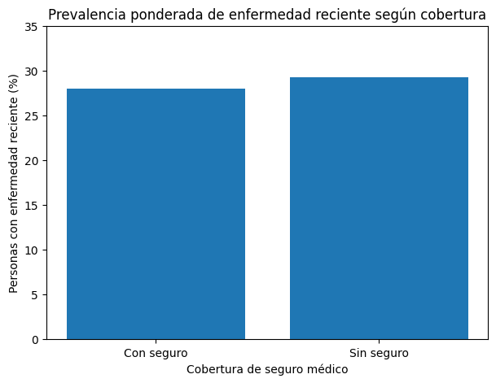

|  | Cobertura | Enfermedad reciente (%) |
| --- | --- | --- |
| 0 | Con seguro | 27.99 |
| 1 | Sin seguro | 29.30 |

```python
# Calculamos la prevalencia ponderada de enfermedad reciente según cobertura.
prevalencia_cobertura = []

for cobertura, grupo in df_analisis.groupby("cobertura_seguro"):
    prevalencia = (
        (grupo["enfermedad_reciente"] * grupo["factor_expansion"]).sum()
        / grupo["factor_expansion"].sum()
        * 100
    )
    prevalencia_cobertura.append({
        "Cobertura": cobertura,
        "Enfermedad reciente (%)": prevalencia
    })

prevalencia_cobertura = pd.DataFrame(prevalencia_cobertura)

plt.figure(figsize=(7, 5))
plt.bar(
    prevalencia_cobertura["Cobertura"],
    prevalencia_cobertura["Enfermedad reciente (%)"]
)
plt.title("Prevalencia ponderada de enfermedad reciente según cobertura")
plt.xlabel("Cobertura de seguro médico")
plt.ylabel("Personas con enfermedad reciente (%)")
plt.ylim(0, 35)
plt.show()

prevalencia_cobertura.round(2)
```

**Análisis:** la prevalencia ponderada de enfermedad reciente es aproximadamente **29,30 % entre las personas sin seguro** y **27,99 % entre quienes poseen seguro**. La diferencia observada es pequeña, de alrededor de **1,31 puntos porcentuales**. En esta fase se interpreta únicamente como una diferencia descriptiva; todavía no permite afirmar que exista una asociación estadísticamente significativa.

### 5.2 Distribución de los tipos de seguro

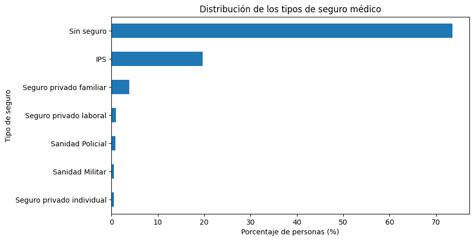

```python
distribucion_seguro = (
    df_analisis["tipo_seguro"]
    .value_counts(normalize=True)
    .mul(100)
    .sort_values(ascending=True)
)

plt.figure(figsize=(9, 5))
distribucion_seguro.plot(kind="barh")
plt.title("Distribución de los tipos de seguro médico")
plt.xlabel("Porcentaje de personas (%)")
plt.ylabel("Tipo de seguro")
plt.show()
```

**Análisis:** la categoría **Sin seguro** concentra la mayor parte de las observaciones. Entre quienes sí poseen cobertura, **IPS** es ampliamente la modalidad más frecuente. Esto muestra una fuerte concentración de la cobertura en pocas categorías y justifica utilizar `tiene_seguro` como variable principal para la pregunta de investigación.

### 5.3 Distribución de la edad

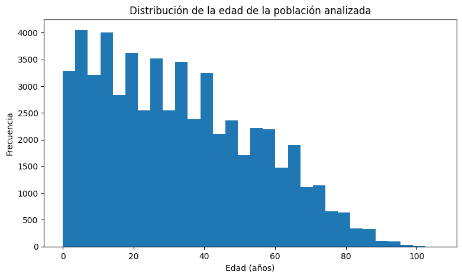

```python
plt.figure(figsize=(9, 5))
df_analisis["edad"].dropna().plot(
    kind="hist",
    bins=30
)
plt.title("Distribución de la edad de la población analizada")
plt.xlabel("Edad (años)")
plt.ylabel("Frecuencia")
plt.show()
```

**Análisis:** la edad presenta una distribución amplia y una asimetría positiva leve. La media es cercana a **32,95 años** y la mediana a **30 años**, por lo que ambas medidas son relativamente próximas, aunque la mediana continúa siendo una medida más robusta frente a los valores de mayor edad.

### 5.4 Edad según enfermedad reciente

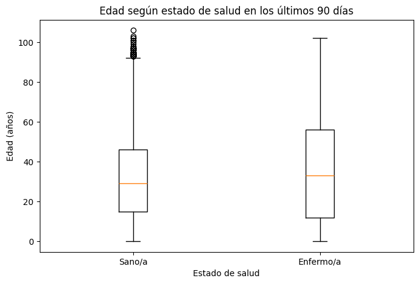

```python
grupos_edad = [
    df_analisis.loc[df_analisis["enfermedad"] == "Sano/a", "edad"].dropna(),
    df_analisis.loc[df_analisis["enfermedad"] == "Enfermo/a", "edad"].dropna()
]

plt.figure(figsize=(8, 5))
plt.boxplot(
    grupos_edad,
    tick_labels=["Sano/a", "Enfermo/a"]
)
plt.title("Edad según estado de salud en los últimos 90 días")
plt.xlabel("Estado de salud")
plt.ylabel("Edad (años)")
plt.show()
```

**Análisis:** las personas que reportaron enfermedad reciente presentan una edad central algo mayor. La mediana es aproximadamente **33 años entre enfermos/as** y **29 años entre sanos/as**. Las distribuciones se superponen ampliamente, por lo que esta diferencia debe analizarse formalmente antes de extraer conclusiones generales.

### 5.5 Ingreso per cápita según cobertura de seguro

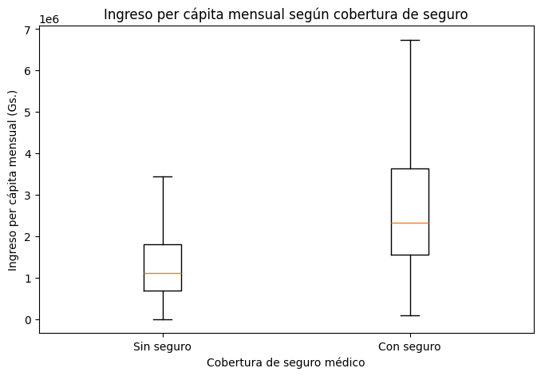

```python
grupos_ingreso = [
    df_analisis.loc[
        df_analisis["cobertura_seguro"] == "Sin seguro",
        "ingreso_per_capita_mensual"
    ].dropna(),
    df_analisis.loc[
        df_analisis["cobertura_seguro"] == "Con seguro",
        "ingreso_per_capita_mensual"
    ].dropna()
]

plt.figure(figsize=(8, 5))
plt.boxplot(
    grupos_ingreso,
    tick_labels=["Sin seguro", "Con seguro"],
    showfliers=False
)
plt.title("Ingreso per cápita mensual según cobertura de seguro")
plt.xlabel("Cobertura de seguro médico")
plt.ylabel("Ingreso per cápita mensual (Gs.)")
plt.show()
```

**Análisis:** el ingreso central es mayor entre las personas con seguro. La mediana es aproximadamente **2,32 millones de Gs.** para quienes poseen cobertura y **1,12 millones de Gs.** para quienes no poseen seguro. Los puntos extremos se ocultan únicamente en esta visualización para facilitar la lectura de las cajas; **no se eliminaron registros del análisis**.

### 5.6 Relación entre edad e ingreso per cápita mensual

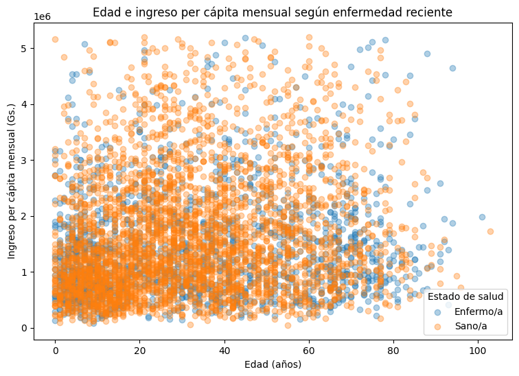

```python
# Para mejorar la legibilidad del gráfico se toma una muestra reproducible
# y se muestran ingresos hasta el percentil 95 únicamente en la visualización.
p95_ingreso = df_analisis["ingreso_per_capita_mensual"].quantile(0.95)

datos_scatter = (
    df_analisis.loc[
        df_analisis["ingreso_per_capita_mensual"] <= p95_ingreso,
        ["edad", "ingreso_per_capita_mensual", "enfermedad"]
    ]
    .dropna()
    .sample(n=min(5000, len(df_analisis)), random_state=42)
)

plt.figure(figsize=(9, 6))

for estado, grupo in datos_scatter.groupby("enfermedad"):
    plt.scatter(
        grupo["edad"],
        grupo["ingreso_per_capita_mensual"],
        alpha=0.35,
        label=estado
    )

plt.title("Edad e ingreso per cápita mensual según enfermedad reciente")
plt.xlabel("Edad (años)")
plt.ylabel("Ingreso per cápita mensual (Gs.)")
plt.legend(title="Estado de salud")
plt.show()
```

**Análisis:** no se observa una relación lineal fuerte entre edad e ingreso. La nube de puntos presenta alta dispersión y una superposición considerable entre personas enfermas y sanas, consistente con las correlaciones bajas calculadas en la Etapa 4.

### 5.7 Mapa de calor de correlaciones numéricas

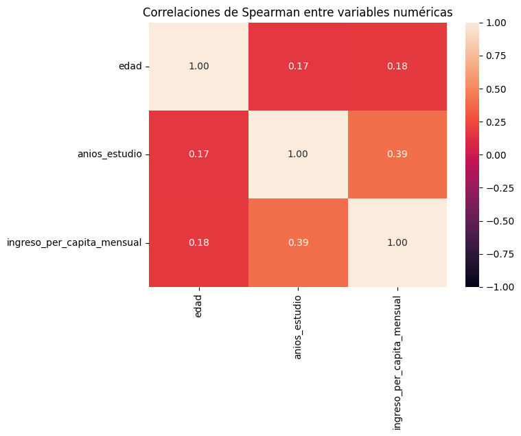

```python
variables_correlacion = [
    "edad",
    "anios_estudio",
    "ingreso_per_capita_mensual"
]

correlacion_eda = (
    df_analisis[variables_correlacion]
    .corr(method="spearman")
)

plt.figure(figsize=(7, 5))
sns.heatmap(
    correlacion_eda,
    annot=True,
    fmt=".2f",
    vmin=-1,
    vmax=1
)
plt.title("Correlaciones de Spearman entre variables numéricas")
plt.show()
```

**Análisis:** las relaciones son positivas pero débiles o moderadas. La asociación más marcada aparece entre **años de estudio e ingreso per cápita**, con una correlación de Spearman cercana a **0,39**. Se utiliza Spearman en esta visualización porque el ingreso presenta una fuerte asimetría y valores extremos; esto no implica una relación causal.

### 5.8 Enfermedad reciente según quintil de ingreso

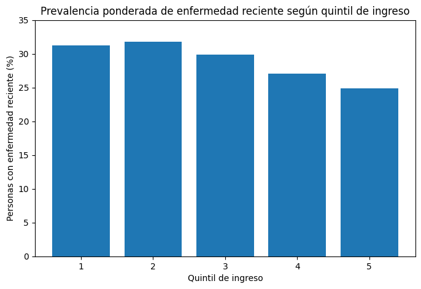

|  | Quintil de ingreso | Enfermedad reciente (%) |
| --- | --- | --- |
| 0 | 1 | 31.21 |
| 1 | 2 | 31.76 |
| 2 | 3 | 29.84 |
| 3 | 4 | 27.03 |
| 4 | 5 | 24.84 |

```python
prevalencia_quintil = []

for quintil, grupo in df_analisis.dropna(subset=["quintil_ingreso"]).groupby("quintil_ingreso"):
    prevalencia = (
        (grupo["enfermedad_reciente"] * grupo["factor_expansion"]).sum()
        / grupo["factor_expansion"].sum()
        * 100
    )
    prevalencia_quintil.append({
        "Quintil de ingreso": int(quintil),
        "Enfermedad reciente (%)": prevalencia
    })

prevalencia_quintil = pd.DataFrame(prevalencia_quintil)

plt.figure(figsize=(8, 5))
plt.bar(
    prevalencia_quintil["Quintil de ingreso"].astype(str),
    prevalencia_quintil["Enfermedad reciente (%)"]
)
plt.title("Prevalencia ponderada de enfermedad reciente según quintil de ingreso")
plt.xlabel("Quintil de ingreso")
plt.ylabel("Personas con enfermedad reciente (%)")
plt.ylim(0, 35)
plt.show()

prevalencia_quintil.round(2)
```

**Análisis:** los quintiles de menores ingresos presentan una prevalencia descriptiva de enfermedad mayor que el quintil más alto. La estimación ponderada es cercana a **31,21 % en el quintil 1**, **31,76 % en el quintil 2** y disminuye hasta aproximadamente **24,84 % en el quintil 5**. El patrón resulta relevante para las fases siguientes, pero todavía no constituye evidencia inferencial.

### 5.9 Comparación complementaria por sexo y área

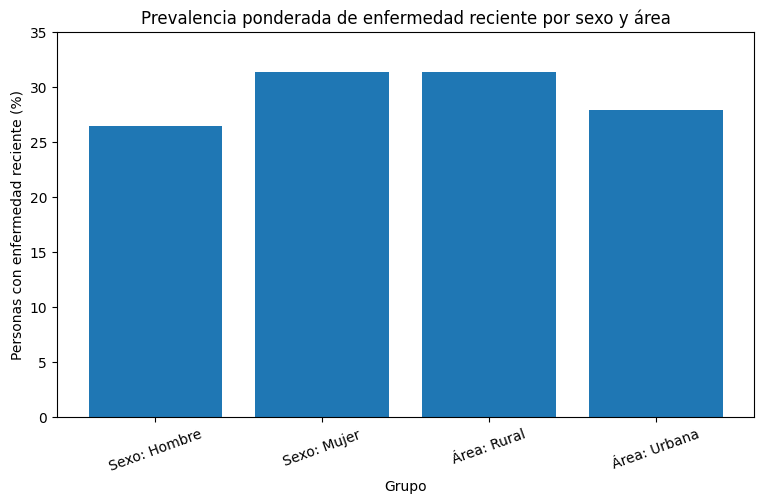

|  | Grupo | Enfermedad reciente (%) |
| --- | --- | --- |
| 0 | Sexo: Hombre | 26.50 |
| 1 | Sexo: Mujer | 31.34 |
| 2 | Área: Rural | 31.42 |
| 3 | Área: Urbana | 27.89 |

```python
comparacion_sexo_area = []

for variable, nombre in [("sexo", "Sexo"), ("area", "Área")]:
    for categoria, grupo in df_analisis.groupby(variable):
        prevalencia = (
            (grupo["enfermedad_reciente"] * grupo["factor_expansion"]).sum()
            / grupo["factor_expansion"].sum()
            * 100
        )
        comparacion_sexo_area.append({
            "Grupo": f"{nombre}: {categoria}",
            "Enfermedad reciente (%)": prevalencia
        })

comparacion_sexo_area = pd.DataFrame(comparacion_sexo_area)

plt.figure(figsize=(9, 5))
plt.bar(
    comparacion_sexo_area["Grupo"],
    comparacion_sexo_area["Enfermedad reciente (%)"]
)
plt.title("Prevalencia ponderada de enfermedad reciente por sexo y área")
plt.xlabel("Grupo")
plt.ylabel("Personas con enfermedad reciente (%)")
plt.ylim(0, 35)
plt.xticks(rotation=20)
plt.show()

comparacion_sexo_area.round(2)
```

**Análisis:** descriptivamente, la enfermedad reciente es más frecuente entre **mujeres (31,34 %)** que entre **hombres (26,50 %)**, y en el **área rural (31,42 %)** que en el **área urbana (27,89 %)**. Estos resultados sugieren variables relevantes para controlar o estudiar en las fases inferencial y predictiva.

### 5.10 Serie temporal trimestral

La serie temporal se construye con los cuatro REG02 trimestrales oficiales de la EPHC 2024. La base anual principal no contiene trimestre ni fecha de entrevista.

Los REG02 trimestrales suministrados no contienen `S01A` ni `S03`, por lo que no permiten calcular cobertura de seguro o enfermedad reciente por trimestre. Para evitar inventar datos, se utiliza la **composición ponderada urbana/rural** como serie temporal contextual. `AREA` es una variable común a los cuatro archivos y también forma parte del análisis principal, donde se observaron diferencias descriptivas de enfermedad entre área urbana y rural.

|  | trimestre | area | porcentaje |
| --- | --- | --- | --- |
| 0 | 1 | Rural | 29.07 |
| 1 | 1 | Urbana | 70.93 |
| 2 | 2 | Rural | 28.96 |
| 3 | 2 | Urbana | 71.04 |
| 4 | 3 | Rural | 28.86 |
| 5 | 3 | Urbana | 71.14 |
| 6 | 4 | Rural | 28.75 |
| 7 | 4 | Urbana | 71.25 |

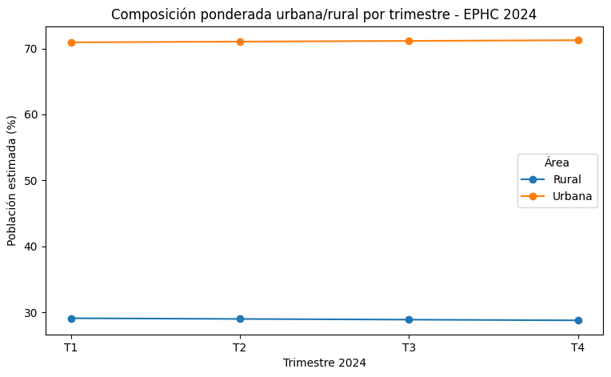

```python
from pathlib import Path

archivos_trimestrales = {
    1: Path("../data/temporal/REG02_EPHC_2024_T1.csv"),
    2: Path("../data/temporal/REG02_EPHC_2024_T2.csv"),
    3: Path("../data/temporal/REG02_EPHC_2024_T3.csv"),
    4: Path("../data/temporal/REG02_EPHC_2024_T4.csv"),
}

partes = []

for trimestre, ruta in archivos_trimestrales.items():
    tmp = pd.read_csv(
        ruta,
        sep=";",
        encoding="utf-8-sig",
        low_memory=False
    )

    factor_trimestral = (
        "Factor" if "Factor" in tmp.columns
        else "factor" if "factor" in tmp.columns
        else "FACTOR"
    )

    tmp = tmp[["AREA", factor_trimestral]].copy()
    tmp["trimestre"] = trimestre
    tmp["factor_expansion"] = pd.to_numeric(
        tmp[factor_trimestral],
        errors="coerce"
    )
    tmp["area"] = tmp["AREA"].map({1: "Urbana", 6: "Rural"})
    partes.append(tmp[["trimestre", "area", "factor_expansion"]])

df_temporal = pd.concat(partes, ignore_index=True)

serie_temporal = (
    df_temporal
    .groupby(["trimestre", "area"], as_index=False)["factor_expansion"]
    .sum()
)

serie_temporal["porcentaje"] = (
    serie_temporal["factor_expansion"]
    / serie_temporal.groupby("trimestre")["factor_expansion"].transform("sum")
    * 100
)

display(serie_temporal[["trimestre", "area", "porcentaje"]].round(2))

plt.figure(figsize=(9, 5))

for area, grupo in serie_temporal.groupby("area"):
    plt.plot(
        grupo["trimestre"],
        grupo["porcentaje"],
        marker="o",
        label=area
    )

plt.xticks([1, 2, 3, 4], ["T1", "T2", "T3", "T4"])
plt.xlabel("Trimestre 2024")
plt.ylabel("Población estimada (%)")
plt.title("Composición ponderada urbana/rural por trimestre - EPHC 2024")
plt.legend(title="Área")
plt.show()
```

**Análisis:** la composición territorial estimada es muy estable durante 2024. La proporción urbana pasa de aproximadamente **70,93 % en T1** a **71,25 % en T4**, mientras que la rural disminuye de **29,07 %** a **28,75 %**. No se observa un quiebre temporal importante. Esta serie se interpreta como contexto de composición de la población, no como evolución trimestral de enfermedad o seguro, variables que no están disponibles en los REG02 trimestrales suministrados.

### 5.11 Patrones y anomalías relevantes identificados

A partir del análisis exploratorio se destacan los siguientes hallazgos:

1. **Diferencia pequeña de enfermedad según cobertura.** La prevalencia ponderada es aproximadamente **29,30 %** entre personas sin seguro y **27,99 %** entre personas con seguro. La magnitud descriptiva de la diferencia es de alrededor de **1,31 puntos porcentuales**.
2. **Los grupos con y sin seguro tienen perfiles socioeconómicos diferentes.** Las personas con seguro presentan medianas mayores de edad, años de estudio e ingreso per cápita. Esto indica que cualquier relación entre seguro y enfermedad debe interpretarse considerando posibles variables asociadas.
3. **Se observa un gradiente descriptivo por nivel de ingreso.** La prevalencia de enfermedad es mayor en los primeros quintiles y menor en el quintil 5. El patrón deberá contrastarse formalmente antes de generalizarlo.
4. **El ingreso presenta valores extremos y una marcada asimetría positiva.** La media supera ampliamente a la mediana y existen observaciones muy elevadas. Estos registros no fueron eliminados por no existir evidencia de que sean errores; para describir el ingreso típico resultan más apropiadas la mediana y los percentiles.
5. **Sexo y área muestran diferencias descriptivas.** La prevalencia ponderada es mayor entre mujeres y en áreas rurales. Estos factores pueden ser relevantes tanto para la inferencia como para el modelado predictivo.
6. **La composición urbana/rural es estable durante 2024.** La serie trimestral contextual no muestra cambios bruscos en la proporción estimada de población urbana y rural.

### 5.12 Hipótesis preliminares para la Fase 2

Los patrones observados permiten formular las siguientes hipótesis, que se contrastarán formalmente en la siguiente fase:

1. **Cobertura y enfermedad:** la proporción de personas que reportan enfermedad reciente difiere entre quienes poseen y quienes no poseen cobertura de seguro médico.
2. **Edad y enfermedad:** la distribución de la edad difiere entre personas que reportaron enfermedad reciente y personas clasificadas como sanas.
3. **Nivel de ingreso y enfermedad:** la ocurrencia de enfermedad reciente no se distribuye de la misma manera entre los quintiles de ingreso.
4. **Educación e ingreso:** existe asociación positiva entre los años de estudio y el ingreso per cápita mensual.
5. **Área y enfermedad:** la proporción de enfermedad reciente difiere entre el área urbana y el área rural.

La selección de las pruebas estadísticas y la verificación de sus supuestos se realizará en la Fase 2; en esta etapa las hipótesis se consideran preliminares y derivadas del EDA.

### Cierre de la Etapa 5

El análisis exploratorio permite responder parcialmente la pregunta de investigación: **en los datos observados, las personas sin seguro presentan una proporción de enfermedad reciente ligeramente mayor que las personas con seguro**.

Sin embargo, la diferencia es pequeña y los grupos también presentan diferencias en edad, educación e ingreso. Por ello, el análisis descriptivo no permite atribuir la diferencia observada a la cobertura de seguro ni establecer causalidad.

La dimensión temporal se completó con los REG02 trimestrales oficiales mediante una serie contextual de composición urbana/rural. Debido a que esos archivos no contienen `S01A` ni `S03`, no se construyó una evolución trimestral artificial de seguro o enfermedad.

## 6. Conclusión de la Fase 1

El análisis descriptivo de la EPHC 2024 muestra que la enfermedad reciente es frecuente en la población estudiada y que, descriptivamente, las personas sin cobertura de seguro médico presentan una proporción algo mayor que quienes poseen seguro. Utilizando el factor de expansión de la versión oficial suministrada, la prevalencia estimada es aproximadamente **29,30 % entre personas sin seguro** y **27,99 % entre personas con seguro**, una diferencia de alrededor de **1,31 puntos porcentuales**.

Esta diferencia es pequeña y no puede interpretarse como evidencia causal ni como significancia estadística. Además, los grupos con y sin seguro presentan perfiles distintos: quienes poseen seguro tienen, en términos descriptivos, mayor edad, más años de estudio y un ingreso per cápita mediano considerablemente superior. Estas diferencias justifican que la relación entre cobertura y enfermedad sea estudiada posteriormente mediante técnicas inferenciales y predictivas que contemplen otras características relevantes.

También emergen otros patrones. La prevalencia ponderada de enfermedad es mayor entre mujeres que entre hombres y en el área rural respecto del área urbana. Por nivel socioeconómico se observa una disminución general de la prevalencia hacia los quintiles de ingreso más altos. El ingreso per cápita presenta una distribución fuertemente asimétrica y valores extremos, razón por la cual la mediana y los percentiles resultan más adecuados que la media para resumirlo.

La dimensión temporal se completó con los cuatro REG02 trimestrales oficiales de 2024. Como estos archivos no contienen las variables `S01A` y `S03`, la serie temporal se construyó con la composición ponderada urbana/rural, una variable contextual también utilizada en el análisis principal. La proporción urbana se mantiene cercana al 71 % durante los cuatro trimestres, sin quiebres relevantes.

Entre las limitaciones se encuentran el carácter observacional de la encuesta, el autorreporte de enfermedad, la presencia de faltantes en variables socioeconómicas y la imposibilidad de establecer causalidad a partir de asociaciones descriptivas. La exclusión de accidentes fue deliberada para mantener coherencia con el fenómeno de enfermedad reciente estudiado.